# data_analyst_recruitment_information

> 本项目主要内容是利用pandas进行数据读取，数据概述，数据清洗和整理，分析和可视化。本项目源自知乎专栏[运营大湿兄 - 秦路](https://zhuanlan.zhihu.com/p/27784143)。

## 加载包

```python
import pandas as pd
import numpy as np
import matplotlib.pyplot as plt
%matplotlib inline
plt.style.use('ggplot') # 使用R语言中的ggplot2绘图配色风格
plt.rcParams['font.sans-serif'] = ['SimHei'] # 图表中正常显示中文标签
plt.rcParams['axes.unicode_minus'] = False # 解决某些负号`-`显示不正常
pd.options.mode.chained_assignment = None  # default='warn'
```

## 加载数据并处理

```python
df = pd.read_csv('DataAnalyst.csv', encoding = 'gb2312')

# 预览数据
df.head(2)
```

|  | city | companyFullName | companyId | companyLabelList | companyShortName | companySize | businessZones | firstType | secondType | education | industryField | positionId | positionAdvantage | positionName | positionLables | salary | workYear |
| --- | --- | --- | --- | --- | --- | --- | --- | --- | --- | --- | --- | --- | --- | --- | --- | --- | --- |
| 0 | 上海 | 纽海信息技术(上海)有限公司 | 8581 | ['技能培训', '节日礼物', '带薪年假', '岗位晋升'] | 1号店 | 2000人以上 | ['张江'] | 技术 | 数据开发 | 硕士 | 移动互联网 | 2537336 | 知名平台 | 数据分析师 | ['分析师', '数据分析', '数据挖掘', '数据'] | 7k-9k | 应届毕业生 |
| 1 | 上海 | 上海点荣金融信息服务有限责任公司 | 23177 | ['节日礼物', '带薪年假', '岗位晋升', '扁平管理'] | 点融网 | 500-2000人 | ['五里桥', '打浦桥', '制造局路'] | 技术 | 数据开发 | 本科 | 金融 | 2427485 | 挑战机会,团队好,与大牛合作,工作环境好 | 数据分析师-CR2017-SH2909 | ['分析师', '数据分析', '数据挖掘', '数据'] | 10k-15k | 应届毕业生 |

我们使用`read_csv`载入数据，常用的还有`read_excel`和`read_table`，后者可以读取txt文件。若是服务器相关部署，还会用到`read_sql`。

`read_csv`有诸多参数，这里设置`encoding = 2312`，改编码常见于Windows系统。此外常见的参数还有`sep`，分隔符（逗号，分号，`\t`）；`header`（是否使用表头作为列名，默认是）；`names`，为列设置额外的名字。

**1. 观察数据结构和信息**：

```python
df.info()
```

```
<class 'pandas.core.frame.DataFrame'>
RangeIndex: 6876 entries, 0 to 6875
Data columns (total 17 columns):
city                 6876 non-null object
companyFullName      6876 non-null object
companyId            6876 non-null int64
companyLabelList     6170 non-null object
companyShortName     6876 non-null object
companySize          6876 non-null object
businessZones        4873 non-null object
firstType            6869 non-null object
secondType           6870 non-null object
education            6876 non-null object
industryField        6876 non-null object
positionId           6876 non-null int64
positionAdvantage    6876 non-null object
positionName         6876 non-null object
positionLables       6844 non-null object
salary               6876 non-null object
workYear             6876 non-null object
dtypes: int64(2), object(15)
memory usage: 913.3+ KB
```

由以上信息可以看出各类字段有6876个数据，其中companyLabelList，businessZones，secondType，positionLables都存在空值；companyId和positionId为数字，其他都是字符串。

**2. 验证是否有重复值**：

我们知道positionId是职位ID，值应该是唯一的，通过该字段查看是否有重复数据：

```python
len(df.positionId.unique())
```

```
5031
```

通过使用`len()`和`unique()`计算出positionId唯一值有5031个，说明有重复值。我们使用`drop_duplicates()`清洗掉。

**3. 清洗重复值**

```python
df_duplicates = df.drop_duplicates(subset = 'positionId', keep = 'first')
df_duplicates.info()
```

```
<class 'pandas.core.frame.DataFrame'>
Int64Index: 5031 entries, 0 to 6766
Data columns (total 17 columns):
city                 5031 non-null object
companyFullName      5031 non-null object
companyId            5031 non-null int64
companyLabelList     4529 non-null object
companyShortName     5031 non-null object
companySize          5031 non-null object
businessZones        3535 non-null object
firstType            5027 non-null object
secondType           5028 non-null object
education            5031 non-null object
industryField        5031 non-null object
positionId           5031 non-null int64
positionAdvantage    5031 non-null object
positionName         5031 non-null object
positionLables       5007 non-null object
salary               5031 non-null object
workYear             5031 non-null object
dtypes: int64(2), object(15)
memory usage: 707.5+ KB
```

`drop_duplicates`函数的`subset`参数选择以哪个列为去重基准，`keep`参数是保留方式，`keep = first`保留第一个删除后边重复值，`last`删除前面重复值保留最后一个。

**4. 薪资数据(salary列)整理**

该项目目的之一就是为了分析招聘薪资的下限和上限，但通过观察数据发现数据内容有小写的`8k`，也有大写的`6K`，甚至还有`9K以上`这种写法（这种情况我们默认上下限相同）。

我们需要用到pandas的`apply`函数，它可以对DataFrame中的一行或一列数据进行操作，允许使用自定义函数。

```python
def cut_word(word, method):
    # 查找`-`处理 `7k-8k`此类数据
    position = word.find('-')
    length = len(word)

    # 处理 `7k-8k`此类数据
    if position != -1:
        bottomSalary = word[:position-1]
        topSalary = word[position+1:length-1]

    # 处理 `9k/9K`以上此类数据
    else:
        bottomSalary = word[:word.upper().find('K')]
        topSalary = bottomSalary

    if method == 'bottom':
        return bottomSalary
    else:
        return topSalary
```

**5. 给原数据添加 bottomSalary 和 topSalary 列：**

```python
df_duplicates['bottomSalary'] = df_duplicates.salary.apply(cut_word, method = 'bottom')
df_duplicates['topSalary'] = df_duplicates.salary.apply(cut_word, method = 'top')
df_duplicates['topSalary'].head()
```

```
0     9
1    15
2     6
3     8
4     3
Name: topSalary, dtype: object
```

**6. 平均薪资**

第五步中求出的薪资都是字符串格式的，我们需要使用`astype`转换为整型：

```python
df_duplicates['bottomSalary'] = df_duplicates.bottomSalary.astype('int')
df_duplicates['topSalary'] = df_duplicates.topSalary.astype('int')
```

在原数据中添加平均薪资数据：

```python
df_duplicates['avgSalary'] = df_duplicates.apply(lambda x: (x.bottomSalary + x.topSalary) / 2,
                                                axis = 1)
df_duplicates.avgSalary.head()
```

```
0     8.0
1    12.5
2     5.0
3     7.0
4     2.5
Name: avgSalary, dtype: float64
```

上面处理平均薪资的代码中我们使用了Python中的lambda匿名函数，`axis`是apply中的参数，`axis = 1`表示函数将用在行方向，`aixs = 0`则是列方向。

**7. 切选出我们想要的数据进行后续分析**

```python
df_clean = df_duplicates[['city', 'companyShortName', 'companySize',
                         'education', 'positionName', 'positionLables',
                         'workYear', 'avgSalary']]

df_clean.head(4)
```

|  | city | companyShortName | companySize | education | positionName | positionLables | workYear | avgSalary |
| --- | --- | --- | --- | --- | --- | --- | --- | --- |
| 0 | 上海 | 1号店 | 2000人以上 | 硕士 | 数据分析师 | ['分析师', '数据分析', '数据挖掘', '数据'] | 应届毕业生 | 8.0 |
| 1 | 上海 | 点融网 | 500-2000人 | 本科 | 数据分析师-CR2017-SH2909 | ['分析师', '数据分析', '数据挖掘', '数据'] | 应届毕业生 | 12.5 |
| 2 | 上海 | SPD | 50-150人 | 本科 | 数据分析师 | ['分析师', '数据分析', '数据'] | 应届毕业生 | 5.0 |
| 3 | 上海 | 数云 | 150-500人 | 本科 | 大数据业务分析师【数云校招】 | ['商业', '分析师', '大数据', '数据'] | 应届毕业生 | 7.0 |

## 描述统计分析

**1. 我们观察下这份招聘数据中各个城市的招聘量：**

```python
df_clean.city.value_counts()
```

```
北京    2347
上海     979
深圳     527
杭州     406
广州     335
成都     135
南京      83
武汉      69
西安      38
苏州      37
厦门      30
长沙      25
天津      20
Name: city, dtype: int64
```

> `value_counts()`的作用是统计所有非零元素的个数，以降序的方式输出Series

从数据中我们可以看到北京对数据分析师的招募需求是遥遥领先的。对那些刚入行数据分析的新手来讲如果在您内城市实在找不到好的工作机会，是否可以去北京一试呢？（感觉在说我自己，泪流满面）

**2. 招聘薪资**

```python
df_clean.describe()
```

|  | avgSalary |
| --- | --- |
| count | 5031.000000 |
| mean | 17.111409 |
| std | 8.996242 |
| min | 1.500000 |
| 25% | 11.500000 |
| 50% | 15.000000 |
| 75% | 22.500000 |
| max | 75.000000 |

我们可以看到，这份招聘数据中，平均薪资为17.1k，中位数是15k，两者相差不大；最大薪资在75k （起码要祝你幸福:)）；标准差是8.99k，有一定的波动性。

**我们用图表来看的更直白一些**

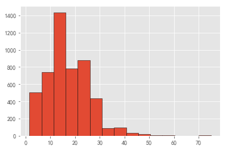

```python
df_clean.avgSalary.hist(bins = 15, edgecolor = 'black')
```

数据分布呈双峰状，因原始数据来源于招聘网站的爬取，薪资很容易集中在某个区间（比如招聘数据给的是10-20k的区间，以本文计算只会落在15k，并非均匀分布）

## 细分分析

**1. 观察不同城市对薪资的影响**

此时轮到箱线图的出场啦！

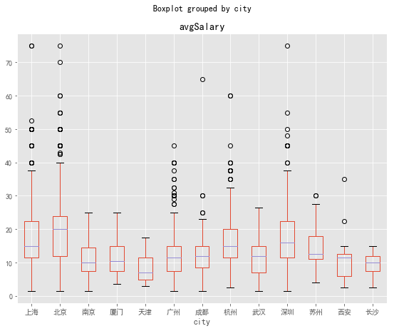

```python
df_clean.boxplot(column = 'avgSalary', by = 'city', figsize = (9, 7))
```

由上图我们可以看出北京的数据分析师薪资高于其他城市，尤其是中位数。上海和深圳稍次，杭州紧随其后，广州这城市...可能太堵了吧。

**2. 学历对薪资的影响**

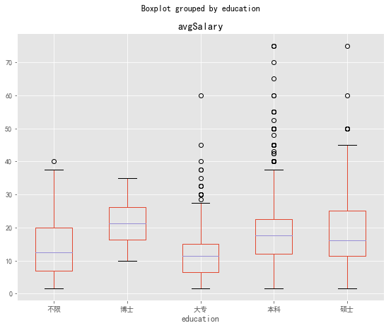

```python
df_clean.boxplot(column = 'avgSalary', by = 'education', figsize = (9, 7))
```

可以看出博士薪资遥遥领先，虽然top区域不如本科和硕士，这点后续会分析。大专学历稍有弱势。

**3. 工作年限对薪资的影响**

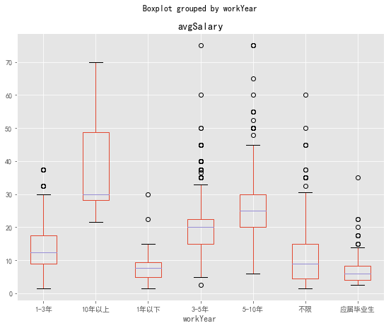

```python
df_clean.sort_values('workYear')
df_clean.boxplot(column = 'avgSalary', by = 'workYear', figsize = (9, 7))
```

从图中可以看出工作年限对薪资的影响还是很大的。

**4. 多维度分析**

我们已经分析了城市、学历和工作年限这些单一变量对薪资的影响，现在可以分析下城市和学历对薪资的影响，这里我们以北京和上海为例。

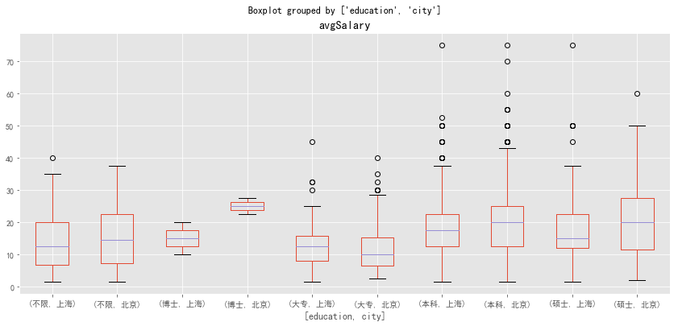

```python
df_sh_bj = df_clean[df_clean['city'].isin(['上海', '北京'])]
df_sh_bj.head(3)

df_sh_bj.boxplot(column = 'avgSalary', by = ['education', 'city'], figsize = (14, 6))
```

上面分析的代码中通过`by`传递多个值箱线图的可读自动变成元组，可以达到横向对比的作用。这种方法不适宜元素过多的场景，我们接下来会介绍`groupby`。

**使用groupby进行多元素分析**

> 和SQL中的group by类似，将不同变量分组

```python
df_clean.groupby(['city', 'education']).mean().head()
```

| city | education | avgSalary |
| --- | --- | --- |
| 上海 | 不限 | 14.051471 |
|  | 博士 | 15.000000 |
|  | 大专 | 13.395455 |
|  | 本科 | 17.987552 |
|  | 硕士 | 19.180000 |

`groupby()`可以传递一组列表，此时得到一组层次化的Series，按城市和学历分组计算了平均薪资。我们可以使用`unstack()`进行行列转置，以便更直观的观察数据。

```python
df_clean.groupby(['city', 'education']).mean().unstack()
```

| education city | avgSalary 不限 | avgSalary 博士 | avgSalary 大专 | avgSalary 本科 | avgSalary 硕士 |
| --- | --- | --- | --- | --- | --- |
| 上海 | 14.051471 | 15.0 | 13.395455 | 17.987552 | 19.180000 |
| 北京 | 15.673387 | 25.0 | 12.339474 | 19.435802 | 19.759740 |
| 南京 | 7.000000 | NaN | 9.272727 | 11.327869 | 13.500000 |
| 厦门 | 12.500000 | NaN | 6.785714 | 11.805556 | 15.750000 |
| 天津 | 3.500000 | NaN | 5.500000 | 9.300000 | NaN |
| 广州 | 9.250000 | NaN | 8.988095 | 14.170259 | 14.571429 |
| 成都 | 10.562500 | NaN | 11.000000 | 13.520202 | 12.750000 |
| 杭州 | 18.269231 | NaN | 12.327586 | 16.823432 | 20.710526 |
| 武汉 | 10.950000 | NaN | 11.214286 | 11.500000 | 7.000000 |
| 深圳 | 15.100000 | 35.0 | 13.898936 | 18.532911 | 18.029412 |
| 苏州 | NaN | NaN | 14.600000 | 14.310345 | 16.833333 |
| 西安 | 8.666667 | NaN | 8.150000 | 12.208333 | 5.000000 |
| 长沙 | 7.642857 | NaN | 9.000000 | 10.633333 | 9.000000 |

不同城市中，博士学历薪资最高的在深圳，硕士学历最高的在杭州，北京综合薪资最好。

我们可以看下不同学历的招聘人数：

```python
df_clean.groupby(['city', 'education']).avgSalary.count().unstack()
```

| education city | 不限 | 博士 | 大专 | 本科 | 硕士 |
| --- | --- | --- | --- | --- | --- |
| 上海 | 68.0 | 3.0 | 110.0 | 723.0 | 75.0 |
| 北京 | 124.0 | 2.0 | 190.0 | 1877.0 | 154.0 |
| 南京 | 5.0 | NaN | 11.0 | 61.0 | 6.0 |
| 厦门 | 3.0 | NaN | 7.0 | 18.0 | 2.0 |
| 天津 | 1.0 | NaN | 4.0 | 15.0 | NaN |
| 广州 | 12.0 | NaN | 84.0 | 232.0 | 7.0 |
| 成都 | 8.0 | NaN | 26.0 | 99.0 | 2.0 |
| 杭州 | 26.0 | NaN | 58.0 | 303.0 | 19.0 |
| 武汉 | 10.0 | NaN | 14.0 | 44.0 | 1.0 |
| 深圳 | 20.0 | 1.0 | 94.0 | 395.0 | 17.0 |
| 苏州 | NaN | NaN | 5.0 | 29.0 | 3.0 |
| 西安 | 3.0 | NaN | 10.0 | 24.0 | 1.0 |
| 长沙 | 7.0 | NaN | 2.0 | 15.0 | 1.0 |

我们可以看出要求博士学历的岗位只有6个。我们计算的平均薪资只取决于公司开出的价码波动性很强，毕竟不是真实的博士的在职薪资。

**5. 不同公司数据分析师招聘需求量**

```python
df_clean.groupby('companyShortName').avgSalary.agg(['count', 'mean']).sort_values(by = 'count',
                                                                                 ascending = False)
```

| companyShortName | count | mean |
| --- | --- | --- |
| 美团点评 | 175 | 21.862857 |
| 滴滴出行 | 64 | 27.351562 |
| 百度 | 44 | 19.136364 |
| 网易 | 36 | 18.208333 |
| 今日头条 | 32 | 17.125000 |
| 腾讯 | 32 | 22.437500 |
| 京东 | 32 | 20.390625 |
| 百度外卖 | 31 | 17.774194 |
| 个推 | 31 | 14.516129 |
| TalkingData | 28 | 16.160714 |
| 宜信 | 27 | 22.851852 |
| 搜狐媒体 | 23 | 25.739130 |
| 饿了么 | 23 | 19.391304 |
| Gridsum 国双 | 23 | 19.086957 |
| 去哪儿网 | 22 | 17.863636 |
| 汽车之家 | 21 | 18.952381 |
| 乐视 | 19 | 21.052632 |
| 京东商城 | 19 | 23.763158 |
| 滴滴出行（小桔科技） | 18 | 34.722222 |
| 人人行(借贷宝) | 17 | 21.088235 |
| 链家网 | 16 | 17.250000 |
| 嘉琪科技 | 16 | 24.625000 |
| 百融金服 | 16 | 17.500000 |
| 易到用车 | 16 | 16.156250 |
| 通联数据 | 16 | 8.843750 |
| 星河互联集团 | 16 | 29.062500 |
| 陌陌 | 15 | 18.566667 |
| 买单侠 | 15 | 18.600000 |
| 有数金服 | 15 | 13.700000 |
| 返利网 | 15 | 23.833333 |
| ... | ... | ... |
| 图灵机器人 | 1 | 32.500000 |
| 国金证券 | 1 | 37.500000 |
| 大观资本 | 1 | 4.500000 |
| 大麦网 | 1 | 55.000000 |
| 天会创投 | 1 | 5.000000 |
| 天会皓闻 | 1 | 3.500000 |
| 太子龙 | 1 | 4.000000 |
| 天骄尚学 | 1 | 10.000000 |
| 天阳科技 | 1 | 11.500000 |
| 天闻数媒 | 1 | 15.000000 |
| 天融互联 | 1 | 20.000000 |
| 天育 | 1 | 7.000000 |
| 天翼阅读文化传播有限公司 | 1 | 15.000000 |
| 天眼互联 | 1 | 7.500000 |
| 天相瑞通 | 1 | 7.500000 |
| 天玑科技 | 1 | 15.000000 |
| 天源迪科 | 1 | 31.500000 |
| 天津赛维斯科技有限公司 | 1 | 5.000000 |
| 天津航空 | 1 | 9.000000 |
| 天津美源星 | 1 | 3.500000 |
| 天津小猫 | 1 | 11.500000 |
| 天气宝 | 1 | 15.000000 |
| 天星资本 | 1 | 11.000000 |
| 天弘基金 | 1 | 25.000000 |
| 天尧信息 | 1 | 15.000000 |
| 天宝 | 1 | 22.500000 |
| 天天果园 | 1 | 17.500000 |
| 天地汇 | 1 | 14.000000 |
| 天同 | 1 | 15.000000 |
| 龙浩通信 | 1 | 5.000000 |

2243 rows × 2 columns

我们可以看出**这份招聘数据中**美团点评对数据分析师的需求量是极其大的，同时也可以得到对数据分析师需求前十的公司愿意支付多少薪水。

**6. 不同城市，招聘数据分析师前5的公司**

这类前几前几的分析问题可能经常出现，我们可以封装一个前N的函数：

```python
def topN(df, n = 5):
    '''
    将传入的数据计数，从大到小排序，返回前n的数据
    '''
    counts = df.value_counts()
    return counts.sort_values(ascending = False)[:n]
```

```python
city_company_dacount_top5 = df_clean.groupby('city').companyShortName.apply(topN)
city_company_dacount_top5.head()
```

```
city
上海    饿了么     23
      美团点评    19
      返利网     15
      买单侠     15
      点融网     11
Name: companyShortName, dtype: int64
```

上边的数据可以清楚的看到每个城市对数据分析师需求最大的top5公司。

**7. 不同城市，职位招聘数前五**

```python
df_clean.groupby('city').positionName.apply(topN).head(10)
```

```
city
上海    数据分析师        79
      大数据开发工程师     37
      数据产品经理       31
      大数据工程师       26
      高级数据分析师      20
北京    数据分析师       238
      数据产品经理      121
      大数据开发工程师     69
      分析师          49
      数据分析         42
Name: positionName, dtype: int64
```

## 图表会说话

**1. 不同城市给出的薪水**

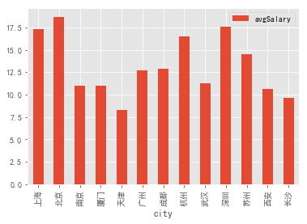

```python
df_clean.groupby('city').mean().plot.bar()
```

**2. 不同城市不同学历给出的薪水**

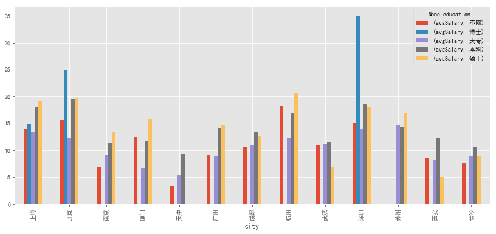

```python
ax = df_clean.groupby(['city', 'education']).mean().unstack().plot.bar(figsize=(14,6))
```

**3. 北京和上海薪资数据对比**

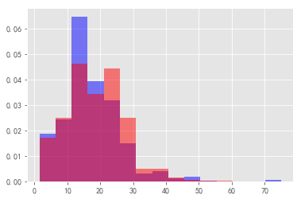

```python
plt.hist(x = df_clean[df_clean.city == '上海'].avgSalary,
         bins = 15,
         normed = 1,
         facecolor = 'blue',
         alpha = 0.5)

plt.hist(x = df_clean[df_clean.city == '北京'].avgSalary,
        bins = 15,
        normed = 1,
        facecolor = 'red',
        alpha = 0.5)

plt.show()
```

因北京和上海需求分析师人数相差较多无法直接对比，用`normed`参数转化为密度。

**4. 对薪资数据深加工，设立不同的level**

```python
bins = [0, 3, 5, 10, 15, 20, 30, 100]
level = ['0~3', '3~5', '5~10', '10~15', '15~20', '20~30', '30+']

df_clean['level'] = pd.cut(df_clean['avgSalary'], bins = bins, labels = level)
```

我们可以预览下数据

```python
df_clean[['avgSalary', 'level']].head(8)
```

|  | avgSalary | level |
| --- | --- | --- |
| 0 | 8.0 | 5~10 |
| 1 | 12.5 | 10~15 |
| 2 | 5.0 | 3~5 |
| 3 | 7.0 | 5~10 |
| 4 | 2.5 | 0~3 |
| 5 | 12.5 | 10~15 |
| 6 | 10.5 | 10~15 |
| 7 | 6.0 | 5~10 |

> `cut`的作用是分桶（数据分析常用方法之一），将不同数据划分出不同等级，即将数值型数据加工分成分类数据，在机器学习的特征工程中应用比较多。参数`level`指定分类（面元）的名称。

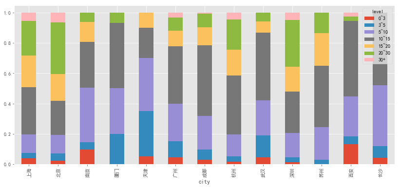

```python
df_level = df_clean.groupby(['city', 'level']).avgSalary.count().unstack()
df_level_prop = df_level.apply(lambda x: x/x.sum(), axis = 1)
df_level_prop.plot.bar(stacked = True, figsize = (14, 6))
```

上面代码中通过`lambda`函数转换百分比，然后作堆积百分比柱形图。我们可以清晰的得出不同等级在不同地区的薪资占比。

```python
df_level_prop.head(5)
```

| level city | 0~3 | 3~5 | 5~10 | 10~15 | 15~20 | 20~30 | 30+ |
| --- | --- | --- | --- | --- | --- | --- | --- |
| 上海 | 0.038815 | 0.034729 | 0.121553 | 0.312564 | 0.209397 | 0.229826 | 0.053115 |
| 北京 | 0.022582 | 0.046442 | 0.124840 | 0.225394 | 0.177248 | 0.340861 | 0.062633 |
| 南京 | 0.096386 | 0.048193 | 0.361446 | 0.301205 | 0.132530 | 0.060241 | NaN |
| 厦门 | NaN | 0.200000 | 0.300000 | 0.433333 | NaN | 0.066667 | NaN |
| 天津 | 0.050000 | 0.300000 | 0.350000 | 0.200000 | 0.100000 | NaN | NaN |

**5. 整理职位标签**

```python
df_clean.positionLables.head()
```

```
0    ['分析师', '数据分析', '数据挖掘', '数据']
1    ['分析师', '数据分析', '数据挖掘', '数据']
2            ['分析师', '数据分析', '数据']
3       ['商业', '分析师', '大数据', '数据']
4      ['分析师', '数据分析', '数据', 'BI']
Name: positionLables, dtype: object
```

**去除`[]`**

`str()`方法允许我们对列中的元素进行字符串相关的处理

```python
df_clean.positionLables.str[1:-1].head()
```

```
0    '分析师', '数据分析', '数据挖掘', '数据'
1    '分析师', '数据分析', '数据挖掘', '数据'
2            '分析师', '数据分析', '数据'
3       '商业', '分析师', '大数据', '数据'
4      '分析师', '数据分析', '数据', 'BI'
Name: positionLables, dtype: object
```

**去除空格**

```python
df_clean.positionLables.str[1:-1].str.replace(' ', '').head()
```

```
0    '分析师','数据分析','数据挖掘','数据'
1    '分析师','数据分析','数据挖掘','数据'
2           '分析师','数据分析','数据'
3       '商业','分析师','大数据','数据'
4      '分析师','数据分析','数据','BI'
Name: positionLables, dtype: object
```

**positionLables本身有空值，需要提出，不然容易报错，我们可以使用`split`方法把元素中的标签拆分成列表：**

```python
word = df_clean.positionLables.str[1:-1].str.replace(' ', '')
df_word = word.dropna().str.split(',').apply(pd.value_counts)
df_word.head()
```

|  | '.NET' | '15天年假' | 'Android' | 'BD' | 'BI' | 'B端' | 'C' | 'C++' | 'C/C++' | 'CRM' | ... | '音视频处理' | '项目管理' | '项目经理' | '顾问' | '风控' | '风险控制' | '餐饮' | '驾照' | '高校' | '高级' |
| --- | --- | --- | --- | --- | --- | --- | --- | --- | --- | --- | --- | --- | --- | --- | --- | --- | --- | --- | --- | --- | --- |
| 0 | NaN | NaN | NaN | NaN | NaN | NaN | NaN | NaN | NaN | NaN | ... | NaN | NaN | NaN | NaN | NaN | NaN | NaN | NaN | NaN | NaN |
| 1 | NaN | NaN | NaN | NaN | NaN | NaN | NaN | NaN | NaN | NaN | ... | NaN | NaN | NaN | NaN | NaN | NaN | NaN | NaN | NaN | NaN |
| 2 | NaN | NaN | NaN | NaN | NaN | NaN | NaN | NaN | NaN | NaN | ... | NaN | NaN | NaN | NaN | NaN | NaN | NaN | NaN | NaN | NaN |
| 3 | NaN | NaN | NaN | NaN | NaN | NaN | NaN | NaN | NaN | NaN | ... | NaN | NaN | NaN | NaN | NaN | NaN | NaN | NaN | NaN | NaN |
| 4 | NaN | NaN | NaN | NaN | 1.0 | NaN | NaN | NaN | NaN | NaN | ... | NaN | NaN | NaN | NaN | NaN | NaN | NaN | NaN | NaN | NaN |

5 rows × 267 columns

上面代码中我们通过apply和value_counts统计标签数组成一张新表。

**用unstack()完成转置**

```python
df_word.unstack().head(8)
```

```
'.NET'  0   NaN
        1   NaN
        2   NaN
        3   NaN
        4   NaN
        5   NaN
        6   NaN
        7   NaN
dtype: float64
```

**将空值删除，重置为DataFram**

```python
df_word.unstack().dropna().reset_index().head(15)
```

|  | level_0 | level_1 | 0 |
| --- | --- | --- | --- |
| 0 | '.NET' | 1397 | 1.0 |
| 1 | '.NET' | 2822 | 1.0 |
| 2 | '.NET' | 3765 | 1.0 |
| 3 | '.NET' | 3949 | 1.0 |
| 4 | '.NET' | 3954 | 1.0 |
| 5 | '.NET' | 4114 | 1.0 |
| 6 | '15天年假' | 1726 | 1.0 |
| 7 | 'Android' | 1821 | 1.0 |
| 8 | 'BD' | 360 | 1.0 |
| 9 | 'BD' | 661 | 1.0 |
| 10 | 'BD' | 667 | 1.0 |
| 11 | 'BD' | 2095 | 1.0 |
| 12 | 'BD' | 2994 | 1.0 |
| 13 | 'BD' | 3071 | 1.0 |
| 14 | 'BD' | 3230 | 1.0 |

level_0位标签名，level_1位df_index的索引，0是该标签在职位中出现的次数。

**词云分析**

```python
from wordcloud import WordCloud
```

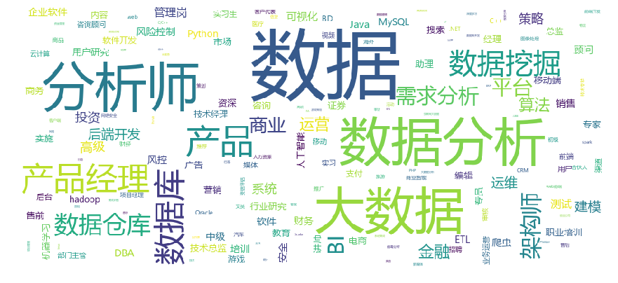

```python
df_word_counts = df_word.unstack().dropna().reset_index().groupby('level_0').count()
df_word_counts.index = df_word_counts.index.str.replace("'", "")

wordcloud = WordCloud(font_path="C:\Windows\Fonts\msyh.ttc",
                    width = 900, height = 400,
                    background_color = 'white')

f, axs = plt.subplots(figsize=(15, 15))
wordcloud.fit_words(df_word_counts.level_1)
axs = plt.imshow(wordcloud)
plt.axis('off')
plt.show()
```